# Apprentissage supervisé - TP1

Les différentes librairies qui seront utilisés pour ce TP sont listées ici. Le code pour générer ce document ainsi que le code R qui a servi de base peuvent être trouvés [ici](https://github.com/MathieuMarauri/apprentissage-2020/blob/master/tp1/output/correction.Rmd) et [là](https://github.com/MathieuMarauri/apprentissage-2020/blob/master/tp1/src/TP1.R).

```r
library("caret") # ensemble de meta-fonctions nécessaires au processus d'apprentissage supervisé
library("class") # fonction knn
library("e1071") # librairie nécessaire pour la fonction tune.knn
library("FNN") # fast KNN
library("ggplot2") # data visualisation
library("klaR") # fonction Naivebayes utilisée avec la librairie caret
library("mlbench") # dataset Vehicle
library("skimr")
```

# Exercice 1 - Règle et risque de Bayes en discrimination binaire

Voici 3 problèmes de discrimination binaire, dans chaque cas on a simulé un échantillon de taille $n = 1000$.

**Cas 1**

Pour $i = 1..1000$, $X_i \sim \mathcal{N}(0, 1)$, $U_i \sim \mathcal{U}[0, 1]$ on a :

$$Y_i = \begin{cases}
\mathbb{1}_{U_i \leq 0,1} & \text{si $X_i \leq 0$}\\
\mathbb{1}_{U_i > 0,2} & \text{si $X_i > 0$}\\
\end{cases}$$
**Cas 2**

Pour $i = 1..1000$, $X_i \sim \mathcal{N}(0, 1)$, $U_i \sim \mathcal{U}[0, 1]$ on a :

$$Y_i = \begin{cases}
\mathbb{1}_{U_i \leq 0,2} & \text{si $X_i \leq 0$}\\
\mathbb{1}_{U_i > 0,4} & \text{si $X_i > 0$}\\
\end{cases}$$

**Cas 3**

On travaille sur des données réelles issues d’une enquête, à partir d’un échantillon tiré au hasard de $n=1000$ consommateurs de café. La variable à expliquer $Y$ est qualitative binaire et prend les modalités “sucré” et “non sucré”. La variable explicative à notre disposition est $X$ qui représente le sexe. On dispose de la table avec en lignes les 1000 consommateurs et en colonnes les 2 variables $X$ et $Y$. Des résultats de statistique bivariée nous donnent :

- Parmi les femmes, on a 20% qui prennent du sucre dans leur café $Y="sucré"$
- Parmi les hommes, on a 10% qui prennent du sucre dans leur café $Y="sucré"$

## Question 1 - Règle de Bayes

> *Donner dans chacun des trois cas, si c’est possible, la règle de Bayes et le risque de Bayes.*

Dans le cas de la discrimination binaire la règle de Bayes est de la forme suivante :

$$\begin{align*}
f^*(x) \colon \mathbb{R} &\to \{0, 1\}\\
x &\mapsto f^*(x) = \begin{cases}
1 & \text{si $P(Y=y|X=x) > 0,5$}\\
0 & \text{sinon}\\
\end{cases}
\end{align*}$$

**Cas 1**

On définie la règle de Bayes en calculant $P(Yi=1|X_i=x_i)$ selon les valeurs de $X$.

Pour $X_i \leq 0$ : $P(Y_i=1|X_i=x_i)=P(U_i \leq 0,1) = 0,1$ d’où $f^*(x_i) = 0$.

Pour $X_i > 0$ : $P(Yi=1|X_i=x_i)=P(U_i > 0,2) = 1 - P(U_i \leq 0,2) = 0,8$ d’où $f^*(x_i) = 1$.

La règle de Bayes est donc :

$$f^*(x) = \begin{cases}
1 & \text{si $x > 0$}\\
0 & \text{sinon}\\
\end{cases}$$

On calcule maintenant l’erreur de Bayes. Elle correspond à la différence entre la prédiction obtenue avec la règle de Bayes, $f^*(X)$, et la vraie valeur, $Y$.

$$\begin{split}
\mathcal{R}^* & = P(Y \neq f^*(X)) \\
& = P(Y = 1 \cap f^*(X) = 0) + P(Y = 0 \cap f^*(X) = 1) \\
& = P(Y = 1 \cap X \leq 0) + P(Y = 0 \cap X > 0) \\
& = P(X \leq 0) \times P(Y = 1 | X \leq 0) + P(X > 0) \times P(Y = 0 | X > 0) \\
& = 0,5 \times 0,1 + 0,5 \times 0,2 \\
& = 0,15
\end{split}$$

**Cas 2**

On définie la règle de Bayes en calculant $P(Yi=1|X_i=x_i)$ selon les valeurs de $X$.

Pour $X_i \leq 0$ : $P(Yi=1|X_i=x_i)=P(U_i \leq 0,2) = 0,2$ d’où $f^*(x_i) = 0$.

Pour $X_i > 0$ : $P(Yi=1|X_i=x_i)=P(U_i > 0,4) = 1 - P(U_i \leq 0,4) = 0,6$ d’où $f^*(x_i) = 1$.

La règle de Bayes est donc :

$$f^*(x) = \begin{cases}
1 & \text{si $x > 0$}\\
0 & \text{sinon}\\
\end{cases}$$

On calcule maintenant l’erreur de Bayes. Elle correspond à la différence entre la prédiction obtenue avec la règle de Bayes, $f^*(X)$, et la vraie valeur, $Y$.

$$\begin{split}
\mathcal{R}^* & = P(Y \neq f^*(X)) \\
& = P(Y = 1 \cap f^*(X) = 0) + P(Y = 0 \cap f^*(X) = 1) \\
& = P(Y = 1 \cap X \leq 0) + P(Y = 0 \cap X > 0) \\
& = P(X \leq 0) \times P(Y = 1 | X \leq 0) + P(X > 0) \times P(Y = 0 | X > 0) \\
& = 0,5 \times 0,2 + 0,5 \times 0,4 \\
& = 0,3
\end{split}$$

**Cas 3**

Comme la loi jointe de $(X, Y)$ n’est pas connue il est impossible de connaître la règle de Bayes et donc l’erreur de Bayes.

## Question 2 - Complexité

> *Est-il possible de donner un indicateur de la complexité de ces problèmes et ainsi de les ordonner en fonction de leur complexité ?*

Le risque de Bayes donne une idée de la complexité du problème. Plus l’erreur théorique minimale est importante plus on considère le problème comme complexe. Ainsi le cas 2 est plus complexe que le premier.

## Question 3 - Simulation

> *Simuler les données du cas 2 et créer en plus un échantillon test de taille 200 (avec le même modèle).*

On va générer un vecteur de $X$ et un vecteur de $Y$ de longueur 1000. On fixe une graine pour que nos résultats soient reproductibles.

```r
# Nombre d'éléments dans l'échantillon
n_train <- 1000

# Générer X selon une loi normale
set.seed(1)
X <- rnorm(n_train)

# Générer U selon une loi uniforme
set.seed(2)
U <- runif(n_train)

# Générer le vecteur réponse Y selon le cas 2
Y1 <- rep(0, n_train)
Y1[X <= 0 & U <= 0.2] <- 1
Y1[X > 0 & U > 0.4] <- 1

# Y est transformé en factor pour faciliter l'utilisation de la fonction tune.knn dans la suite
Y <- as.factor(Y1)

# Créer un data.frame avec X et Y
data <- data.frame(X, Y)
```

Sur le graphe suivant on peut voir la densité de $X$ selon la valeur prise par $Y$.

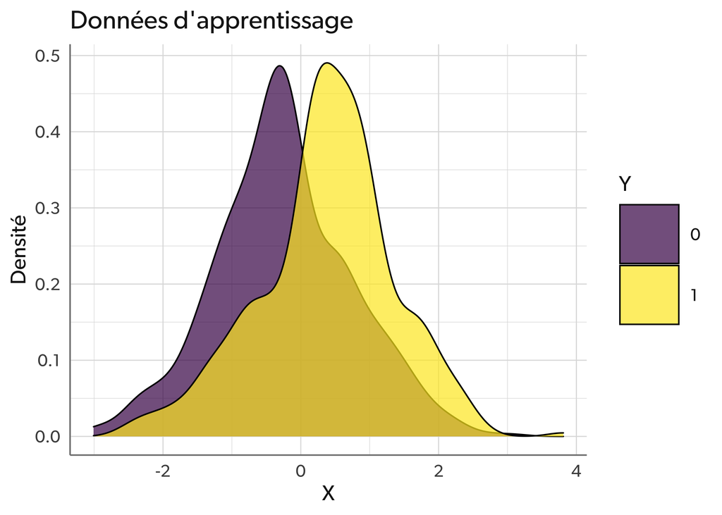

```r
ggplot(
  data = data,
  mapping = aes(x = X, fill = Y)
) +
  geom_density(
    alpha = .7
  ) +
  labs(
    x = "X",
    y = "Densité",
    title = "Données d'apprentissage",
    fill = "Y"
  )
```

De la même manière on peut simuler des données de test qui seront utilisées pour mesurer l’erreur de nos modèles de prédictions.

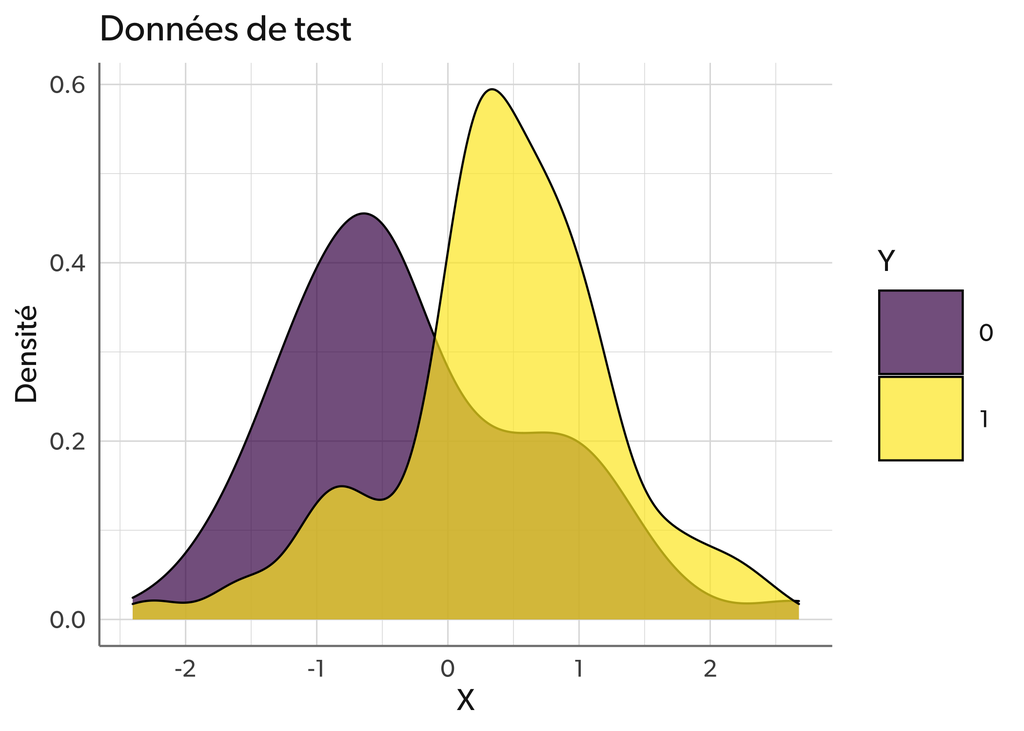

```r
n_test <- 200
set.seed(3)
X <- rnorm(n_test)
set.seed(4)
U <- runif(n_test)
Y2 <- rep(0, n_test)
Y2[X <= 0 & U <= 0.2] <- 1
Y2[X > 0 & U > 0.4] <- 1
Y <- as.factor(Y2)
test <- data.frame(X, Y)
ggplot(
  data = test,
  mapping = aes(x = X, fill = Y)
) +
  geom_density(
    alpha = .7
  ) +
  labs(
    x = "X",
    y = "Densité",
    title = "Données de test",
    fill = "Y"
  )
```

## Question 4 - Knn

> *Quelle est la règle de décision associée à l’algorithme des k plus proches voisins ? Mettre en oeuvre les k plus proches voisins. Justifier le choix des paramètres et commenter les résultats en validation et sur l’échantillon test.*

#### Le modèle KNN

Le modèle des $K$ plus-proches-voisins (*K-nearest-neighbours* en anglais) est un modèle d’apprentissage supervisé utilisable en classification et en régression. Son principe est simple. Pour prédire la classe d’une nouvelle observation, on calcule la distance qui sépare ce nouveau point de tous les points des données d’apprentissage, on sélectionne les $k$ points les plus proches puis on détermine la classe à prédire en faisant un vote à la majorité.

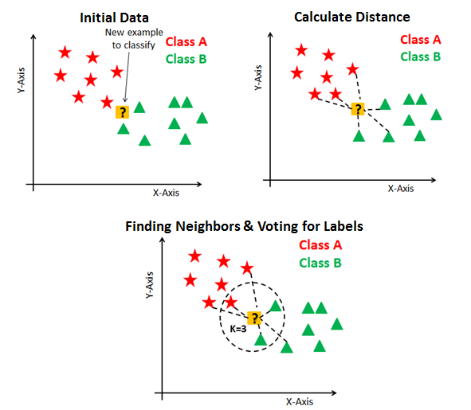

*Quelques points d’attention :*

- L’hyper-paramètre $k$ est bien sûr l’élément central de ce modèle. Il faut choisir sa valeur de manière réfléchie (on verra dans la suite comment procéder).
- La distance utilisée est aussi un point important. On choisira souvent la distance euclidienne mais il est bon de savoir qu’on peut utiliser n’importe quelle mesure de similarité selon les besoins.
- Enfin il faut savoir que plus il y a de prédicteurs plus les plus proches voisins seront potentiellement éloignés, c’est ce que l’on appelle le fléau de la dimension.

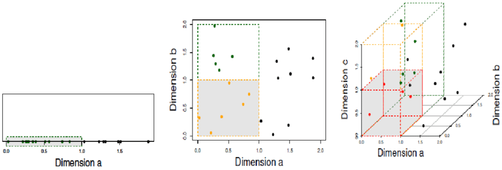

#### La règle de décision

Dans le cas d’une classification, la règle de décision associée aux $k$ plus-proches-voisins est le vote à la majorité. Pour $k=5$ par exemple, si 3 voisins ont $Y=0$ et 2 voisins ont $Y=1$ alors la prédiction sera $\widehat{Y}=0$.

#### Un premier modèle

On commence par lancer un modèle de k plus-proches-voisins avec un choix arbitraire pour $k$, 10 par exemple. Pour des questions de reproductibilité on fixe là aussi une graîne. On utilise la fonction `class::knn()` qui prend 4 paramètres en entrée :

- `train` : les prédicteurs des données d’apprentissage,
- `test` : les prédicteurs des données de tests sur lesquelles se feront les prédictions,
- `cl` : le vecteur de la variable cible des données d’apprentissage,
- `k` : le nombre de plus-proches-voisins souhaité.

```r
set.seed(123456)
knn_pred <- knn(
  train = as.matrix(data$X), # données d'apprentissage
  test = as.matrix(test$X), # données à prédire
  cl = data$Y, # vraies valeurs
  k = 10 # nombre de voisins
)
```

On peut calculer l’erreur et la précision de ce modèle.

```r
# Taux de bonnes prédictions
sum(knn_pred == test$Y) / n_test

# Taux d'erreur
1 - sum(knn_pred == test$Y) / n_test
```

L’erreur est de 0.345.

#### Le choix de $k$

La valeur de $k$ a été définie de façon arbitraire, on peut optimiser ce choix en essayant différentes valeurs et en choisissant la meilleure. Cela se fait en découpant l’échantillon d’apprentissage en une partie apprentissage et une partie validation. La règle de décision est construite sur la partie apprentissage et les prédictions sont faites sur la partie validation. On peut ainsi mesurer une erreur sur des données qui n’ont pas servi à construire la règle de décision, les données de validation. Pour cela on utilise la fonction `e1071::tune.knn()` qui prend 4 paramètres en entrée :

- `x` : les prédicteurs
- `y` : le vecteur cible
- `k` : un vecteur de valeurs de $k$ à tester
- `tunecontrol` : la méthode d’échantillonnage, sous la forme d’une fonction `tune.control(sampling = "cross")` pour de la validation croisée (dans ce cas il faut également spécifier l’argument `cross = 5` pour faire de la 5-fold cv) ou `tune.control(sampling = "boot")` pour faire du bootstrap.

```r
knn_cross_results <- tune.knn(
  x = data$X, # predicteurs
  y = data$Y, # réponse
  k = 1:50, # essayer knn avec K variant de 1 à 50
  tunecontrol = tune.control(sampling = "cross"), # utilisation de la cross validation
  cross = 5 # 5 blocs
)
```

On peut visualiser les erreurs obtenues sur le graphique suivant.

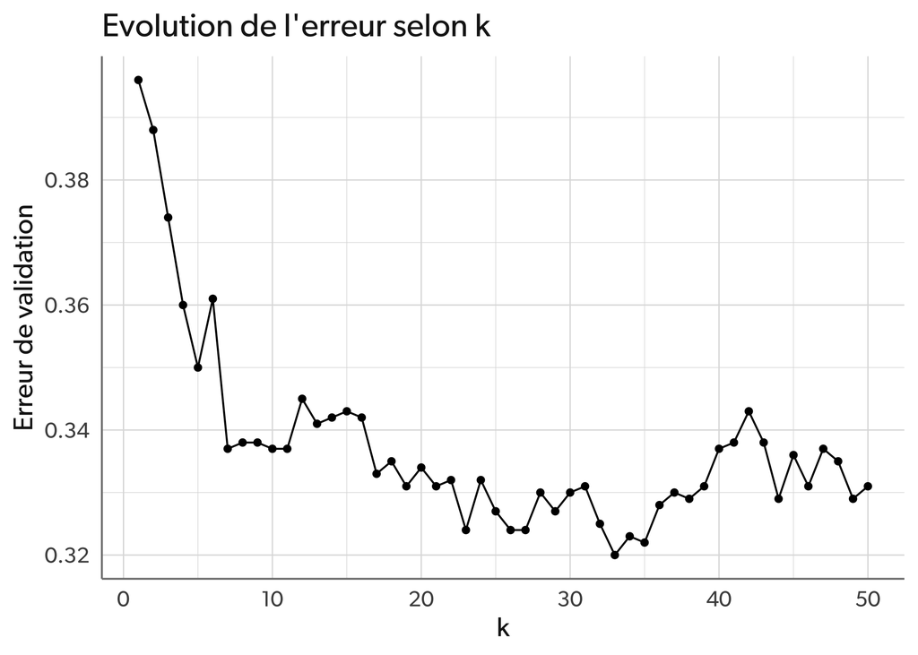

```r
ggplot(
  data = knn_cross_results$performances,
  mapping = aes(x = k, y = error)
) +
  geom_line() +
  geom_point() +
  labs(
    x = "k",
    y = "Erreur de validation",
    title = "Evolution de l'erreur selon k"
  )
```

Le meilleur $k$ est obtenu avec la commande `knn_cross_results$best.parameters$k` : 33. De cette manière le choix de $k$ n’est plus arbitraire mais basé sur nos données et le $k$ donnant l’erreur minimale (sur les données de validation) est choisie.

*Remarque : la valeur optimale de $k$ peut varier à chaque fois que la commande est lancée. On verra dans l’exercice suivant comment on peut contourner ce problème.*

On peut relancer la prédiction avec le $k$ sélectionné et calculer le taux d’erreur comme précédemment.

```r
set.seed(123456)
knn_pred <- knn(
  train = as.matrix(data$X), # données d'apprentissage
  test = as.matrix(test$X), # données à prédire
  cl = data$Y, # vraies valeurs
  k = knn_cross_results$best.parameters$k # nombre de voisins
)
```

L’erreur est de 0.3.

#### Analyse de l’erreur

L’erreur obtenue est très proche de l’erreur de Bayes calculée à la question 1. (Pour $k=30$, avec les mêmes graines, l’erreur est inférieure au risque de Bayes). Cela est due au fait que les données générées ne correspondent pas parfaitement à la loi définie dans l’énoncé du fait du faible nombre d’observations simulées (200). On peut simuler un nombre supérieur de données, 2000 par exemple, et recalculer l’erreur. Pour ce faire on procède comme précédemment.

```r
n_test2 <- 2000
set.seed(3)
X <- rnorm(n_test2)
set.seed(4)
U <- runif(n_test2)
Y2 <- rep(0, n_test2)
Y2[X <= 0 & U <= 0.2] <- 1
Y2[X > 0 & U > 0.4] <- 1
Y <- as.factor(Y2)
test2 <- data.frame(X, Y)
set.seed(123456)
knn_pred2 <- knn(
  train = as.matrix(data$X), # données d'apprentissage
  test = as.matrix(test2$X), # données à prédire
  cl = data$Y, # vraies valeurs
  k = knn_cross_results$best.parameters$k # nombre de voisins
)
```

## Question 5 - Naive Bayes

> *Quelle est la règle de décision associée au bayésien naïf ? Mettre en oeuvre le Bayésien naïf. Justifier le choix des paramètres et commenter les résultats en validation et sur l’échantillon test.*

#### Le modèle bayésien naïf

Ce modèle se base sur la formule de Bayes :

$$P(Y=y|X=x) = \frac{P(Y=y) \times P(X=x|Y=y)}{P(X=x)}$$

#### La règle de décision

Avec le modèle bayésien naïf on calcule $\widehat{P}(Y=y|X=x)$ pour $y=0, 1$. Pour choisir la classe $Y$ on va prendre la probabilité la plus forte, c’est à dire celle qui est supérieur à $0,5$.

#### Un premier modèle

La fonction utilisée pour réaliser un modèle bayésien naïf est la fonction `klaR::NaiveBayes()`. Elle prend 2 paramètres en entrée :

- `formula` : une formule spécifiant le modèle, ici ce sera simplement `Y ~ X`,
- `data` : un data.frame contenant les variables utilisées dans l’argument `formula`

```r
naive_bayes_model <- NaiveBayes(
  formula = Y ~ X,
  data = data
)
```

On peut utiliser ce modèle pour effectuer des prédictions sur le jeu de données de test et ainsi mesurer l’erreur sur des données non utilisées pour apprendre les probabilités $\widehat{P}(Y=y|X=x)$.

```r
naive_bayes_pred <- predict(
  object = naive_bayes_model,
  newdata = test
)
```

Comme précédemment on peut mesurer la précision du modèle ainsi que son erreur de la façon suivante.

```r
# Taux de bonnes prédictions
sum(naive_bayes_pred$class == test$Y) / n_test

# Taux d'erreur
1 - sum(naive_bayes_pred$class == test$Y) / n_test
```

Le taux d’erreur est de 0.39.

#### Le choix des paramètres

Le modèle bayésien naïf a été lancé avec ses paramètres par défaut. 3 hyper-paramètres peuvent être modifiés :

- l’utilisation ou non d’un noyau pour estimer les densités des variables numériques, `usekernel`
- la largeur de bande utilisée par le noyau (ou plus précisément un facteur multiplicatif qui sera appliqué à une largeur de bande pré-définie), `adjust`
- la correction de Laplace à appliquer pour les variables catégorielles, `fL`.

Pour choisir la meilleure combinaison d’hyper-paramètres pour le modèle bayésien naïf, on va diviser notre jeu de données, `data`, en 2 groupes : apprentissage et validation. Comme pour le choix de $k$ dans le modèle des $k$ plus-proches-voisins, le but est d’estimer l’erreur sur les données de validation pour chaque combinaison d’hyper-paramètres et de sélectionner la combinaison avec l’erreur la plus faible.

On commence par spécifier l’ensemble des combinaisons d’hyper-paramètres que l’on souhaite évaluer. Parmi les 3 hyper-paramètres nécessaires seuls 2 seront utilisés dans notre cas : `usekernel` et `adjust`. En effet la correction de Laplace sert pour les variables catégorielles or notre jeu de données ne comporte que des données numériques.

```r
hyperparam_grid <- expand.grid(
  usekernel = TRUE, # si vrai utilisation d'un noyau sinon gaussien
  fL = 0, # correction avec lissage de Laplace (ici ce paramètre n'est pas nécessaire, x étant continue)
  adjust = seq(1, 5, by = 1) # largeur de bande
)
hyperparam_grid <- rbind(hyperparam_grid, data.frame(usekernel = FALSE, fL = 0, adjust = 1))
```

On construit ensuite la séparation entre données d’apprentissage et de validation.

```r
set.seed(123456)
train_index <- sample(1:nrow(data), size = nrow(data) * .8)
validation_index <- setdiff(1:nrow(data), train_index)
train <- data[train_index, ]
validation <- data[validation_index, ]
```

On va maintenant entraîner autant de modèles qu’il y a de combinaisons et calculer l’erreur sur les données de validation pour chacun de ces modèles.

```r
results <- cbind(hyperparam_grid, "error" = 0)
for (i in 1:nrow(results)) {
  naive_bayes_model <- NaiveBayes(
    formula = Y ~ X,
    data = train,
    usekernel = results$usekernel[i],
    fL = results$fL[i],
    adjust = results$adjust[i]
  )
  naive_bayes_pred <- predict(
    object = naive_bayes_model,
    newdata = validation
  )
  results[i, "error"] <- 1 - sum(naive_bayes_pred$class == validation$Y) / length(validation_index)
}
```

On peut visualiser les résultat sous forme graphique pour choisir la combinaison d’hyper-paramètres donnant le meilleur résultat.

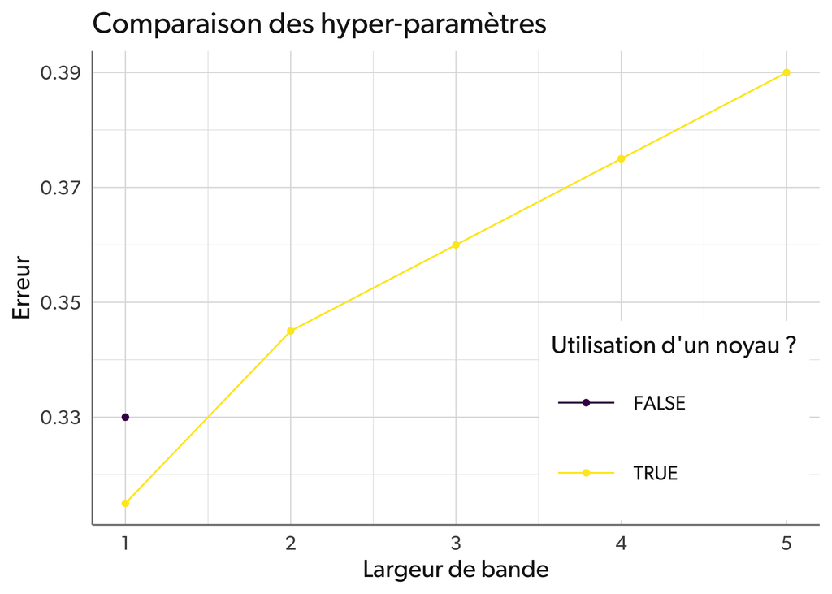

```r
ggplot(
  data = results,
  mapping = aes(x = adjust, y = error, color = usekernel)
) +
  geom_line() +
  geom_point() +
  labs(
    x = "Largeur de bande",
    y = "Erreur",
    title = "Comparaison des hyper-paramètres",
    color = "Utilisation d'un noyau ?"
  ) +
  theme(
    legend.position = c(.8, .22)
  )
```

Le meilleur modèle est obtenu avec l’utilisation d’un noyau pour estimer la densité et une largeur de bande de 1 (plus précisément un facteur multiplicatif de la largeur de bande de 1).

On va donc utiliser ces hyper-paramètres pour effectuer une prédiction sur les données de test et ainsi mesurer l’erreur de généralisation du modèle bayésien naïf. Pour ce faire on va entraîner le modèle avec les hyper-paramètres sélectionnés sur l’ensemble des données train + validation puis effectuer une prédiction sur les données de test.

```r
naive_bayes_model <- NaiveBayes(
  formula = Y ~ X,
  data = data,
  usekernel = TRUE,
  fL = 0,
  adjust = 1
)
naive_bayes_pred <- predict(
  object = naive_bayes_model,
  newdata = test
)
```

Comme précédemment on calcule l’erreur de généralisation. On obtient 0.32.

```r
sum(naive_bayes_pred$class == test$Y) / n_test
1 - sum(naive_bayes_pred$class == test$Y) / n_test
```

#### Analyse de l’erreur

On remarque que l’erreur de validation et l’erreur de test sont légèrement différentes. Les données sur lesquelles l’estimation de l’erreur a été faite sont différentes : les données de validation, sur lesquelles on a choisi les meilleurs hyper-paramètres, et les données de test.

# Exercice 2 - Discrimination à plusieurs classes

On utilisera les K plus proches voisins et Bayésien naïf pour discriminer les 4 types de véhicules (variable à expliquer à 4 modalités) à l’aide de différentes variables décrivant la silhouette d’un véhicule.

## Question 1 - Import des données

> *Charger la table Vehicle après avoir chargé le package `mlbench`. Lire la description de la table. Combien de prédicteurs potentiels dans cette table ?*

On commence par charger la table `Vehicule` avec la commande `data(Vehicle)` et par avoir un aperçu des données contenues dedans. On peut regarder directement les données en affichant le data.frame, visualiser un résumé avec `summary()` ou encore utiliser `skimr::skim()`.

La variable cible est `class`, elle comporte 4 modalités. Les 18 autres variables sont toutes quantitatives et peuvent toutes être utilisées comme prédicteurs.

```r
predicteurs <- names(Vehicle)[-19]
```

*Points d’attention*

Le modèle des k-plus-proches-voisins est sensible au nombre de prédicteurs or ici il y en 18. Une pré-sélection de variables pourrait être la bienvenue.

Toutes les variables explicatives ne sont pas sur la même échelle de valeurs. Il faudra harmoniser les échelles pour que le calcul de distance ne soit pas impacté.

## Question 2 - Fonction de coût

> *Quelle fonction de coût utiliser ?*

$$\mathscr{L}(y, \widehat{y}) = \sum_{i=1}^{n}1_{y_i\neq\widehat{y}_i}$$

Pour calculer cette erreur on va séparer les données en un ensemble d’apprentissage et un ensemble de test. On définit une graine pour pouvoir reproduire les résultats et on choisit un ratio 80/20.

```r
set.seed(123456)
train_index <- sample(1:nrow(Vehicle), size = nrow(Vehicle) * .8)
test_index <- setdiff(1:nrow(Vehicle), train_index)
train <- Vehicle[train_index, ]
test <- Vehicle[test_index, ]
```

## Question 3 - Knn

> *Quelle est la règle de décision associée à l’algorithme des k plus proches voisins ? Mettre en oeuvre les k plus proches voisins. Justifir le choix des paramètres et commenter les résultats.*

Comme dans le cas précédent on va utiliser le vote à la majorité pour choisir la classe. Le choix de la meilleure valeur de $k$ se fait par validation croisée avec la fonction `e1071::tune.knn()`. On a vu que la valeur retournée pouvait varier. On va ici lancer plusieurs fois cette fonction pour ensuite choisir la valeur de $k$ la plus fréquemment retournée.

```r
best_k <- numeric(length = 20)
for (i in 1:20) {
  knn_cross_results <- tune.knn(
    x = scale(train[, predicteurs]),
    y = train[, "Class"],
    k = 1:50,
    tunecontrol = tune.control(sampling = "cross"),
    cross = 5
  )
  best_k[i] <- knn_cross_results$best.parameters[[1]]
  # print(sprintf("Itération %s : meilleur K = %s", i, knn_cross_results$best.parameters))
}
```

| Valeur de K | 3 | 4 | 5 | 6 | 7 | 8 | 12 |
| --- | --- | --- | --- | --- | --- | --- | --- |
| Nombre d’occurences | 5 | 2 | 1 | 4 | 5 | 2 | 1 |

```r
set.seed(123456)
knn_pred <- knn(
  train = as.matrix(scale(train[, predicteurs])), # données d'apprentissage
  test = as.matrix(scale(test[, predicteurs])), # données à prédire
  cl = train[, "Class"], # vraies valeurs
  k = 3 # nombre de voisins
)
```

L’erreur obtenue est 0.294.

## Question 4 - Naive Bayes

> *Quelle est la règle de décision associée au bayésien naïf ? Mettre en oeuvre le Bayésien naïf. Justifier le choix des paramètres et commenter les résultats.*

#### La règle de décision

Comme dans le cas binaire c’est le maximum a posteriori qui est utilisé pour choisir la classe prédite.

#### Le choix des hyper-paramètres

On va ici utiliser la libraire `caret` qui comporte un ensemble de fonction facilitant la création de pipelines d’entraînement en apprentissage supervisé. [Ce livre en ligne](https://topepo.github.io/caret/) et [cette vignette d’introduction](https://cran.r-project.org/web/packages/caret/vignettes/caret.html) donnent une bonne vision du fonctionnement de ce package. On va faire la même chose que dans l’exercice précédent, à savoir évaluer l’erreur de validation pour différentes combinaisons d’hyper-paramètres mais de manière simplifiée.

On définit l’ensemble des combinaisons à tester.

```r
hyperparam_grid <- expand.grid(
  usekernel = TRUE, # si vrai utilisation d'un noyau sinon gaussien
  fL = 0, # correction avec lissage de Laplace (ici ce paramètre n'est pas nécessaire, x étant continue)
  adjust = seq(1, 5, by = 1) # largeur de bande
)
hyperparam_grid <- rbind(hyperparam_grid, data.frame(usekernel = FALSE, fL = 0, adjust = 1))
```

On va définir la façon de séparer les données en apprentissage et validation avec la fonction `caret::trainControl()`. On spécifie l’argument `method` à `"cv"` pour faire de la validation croisée et l’argument `number` à `5` pour utiliser 5 blocs.

```r
control <- trainControl(method = "cv", number = 5)
```

On peut ensuite entraîner le modèle avec la fonction `caret::train()`. Un modèle par combinaison sera entraîné et l’erreur sera calculée sur l’échantillon de validation. La fonction `caret::train()` prend 5 arguments :

- `x` : les prédicteurs
- `y` : le vecteur de la variable cible
- `method` : le nom du modèle à entraîner, ici `"nb"` pour Naive Bayes
- `trControl` : la méthode de validation
- `tunegrid` : la grille d’hyper-paramètres à tester

Cette fonction va choisir les meilleurs hyper-paramètres et retourner le meilleur modèle directement.

```r
naive_bayes <- train(
  x = train[, predicteurs], # prédicteurs
  y = train[, "Class"], # réponse
  method = "nb", # classifieur utilisé, ici Naive Bayes
  trControl = control, # méthode d'échantillonnage, ici 5-fold CV
  tuneGrid = hyperparam_grid # combinaisons d'hyper-paramètres à évaluer
)
```

On peut visualiser les résultats sous forme graphique.

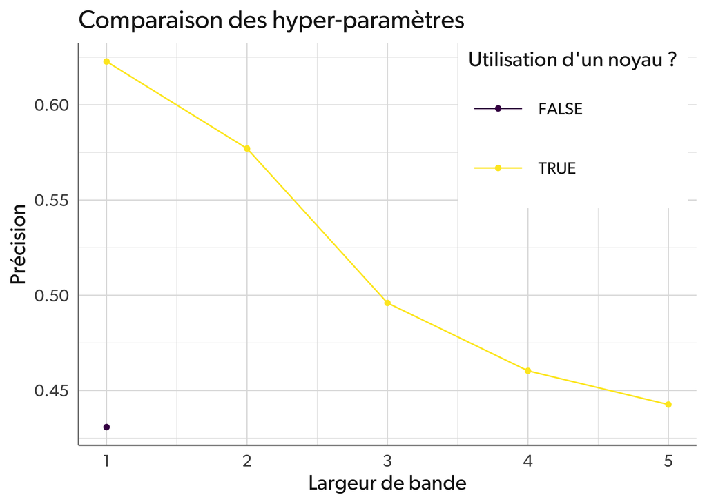

```r
ggplot(
  data = naive_bayes$results,
  mapping = aes(x = adjust, y = Accuracy, color = usekernel)
) +
  geom_line() +
  geom_point() +
  labs(
    x = "Largeur de bande",
    y = "Précision",
    title = "Comparaison des hyper-paramètres",
    color = "Utilisation d'un noyau ?"
  ) +
  theme(
    legend.position = c(.8, .8)
  )
```

Le meilleur modèle est obtenu avec l’utilisation d’un noyau pour estimer la densité et une largeur de bande de 1 (plus précisément un facteur multiplicatif de la largeur de bande de 1).

La fonction `caret::predict()` va utiliser directement le résultat de la fonction `caret::train()` et donc les meilleurs hyper-paramètres pour effectuer la prédiction.

```r
naive_bayes_pred <- predict(
  object = naive_bayes,
  newdata = test
)
```

L’erreur de généralisation est de 0.424.

#### Pourquoi des *warnings* ?

On peut remarquer que la fonction `predict()` génère des messages de *warning* de la forme : `Numerical 0 probability for all classes with observation`. Cela veut dire que les 4 probabilités initialement calculées par le modèle sont toutes très faibles. Il s’agit des $P(Y = y) \times P(X = x|Y=y)$. Leur comparaison n’est donc peut-être pas pertinente. La fonction renvoie ces probabilités normalisées donc ces faibles valeurs n’apparaissent pas lorsqu’on regarde les résultats du modèle (utiliser la commande `predict(naive_bayes, test, type = "prob")` pour avoir les probabilités et non pas les classes directement).

# Exercice 3 - Problème de régression

**Context**: Since 2008, guests and hosts have used Airbnb to expand on traveling possibilities and present more unique, personalized way of experiencing the world. This dataset describes the listing activity and metrics in NYC, NY for 2019.

**Content**: This data file includes all needed information to nd out more about hosts, geographical availability, necessary metrics to make predictions and draw conclusions.

**Acknowledgements** This public dataset is part of Airbnb, and the original source can be found on this website.

**Source**: kaggle and Airbnb.

- id : listing ID
- name : name of the listing
- host id : host ID
- host name : name of the host
- neighbourhood group : location
- neighbourhood : area
- latitude : latitude coordinates
- longitude : longitude coordinates
- room type listing : space type
- price : price in dollars
- minimum nights : amount of nights minimum
- number of reviews : number of reviews
- last review : latest review
- reviews per month : number of reviews per month
- calculated host listings count : amount of listing per host
- availability 365 : number of days when listing is available for booking

La variable à expliquer est *price*.

## Question 1 - Choix des variables

> *Quelles variables explicatives proposez-vous d’utiliser si vous êtes un particulier et que vous souhaitez prédire à quel prix vous pourriez proposer votre logement en Airbnb en vous positionnant “au prix du marché”.*

Ici les seuls régresseurs utilisables pour un particulier qui n’est pas encore inscrit sur Airbnb sont les variables de localisation (peut-être une sélection parmi les 4), et le type de logement (room_type). La variable à prédire est, cette fois, une variable quantitative (price).

## Question 2 - Fonction de coût

> *Quelle fonction de coût utiliser ?*

– Mathieu Marauri